# Prediction Assignment Writeup

# Project Description and Goal

Using devices such as Jawbone Up, Nike FuelBand, and Fitbit it is now possible to collect a large amount of data about personal activity relatively inexpensively.  
These type of devices are part of the quantified self movement - a group of enthusiasts who take measurements about themselves regularly to improve their health, to find patterns in their behavior, or because they are tech geeks.  
One thing that people regularly do is quantify how much of a particular activity they do, but they rarely quantify how well they do it.  
In this project, the goal is to use data from accelerometers on the belt, forearm, arm, and dumbell of 6 participants. They were asked to perform barbell lifts correctly and incorrectly in 5 different ways.  
More information is available from the website here: http://groupware.les.inf.puc-rio.br/har (see the section on the Weight Lifting Exercise Dataset). The training data for this project are available here:  
https://d396qusza40orc.cloudfront.net/predmachlearn/pml-training.csv  
The test data are available here:  
https://d396qusza40orc.cloudfront.net/predmachlearn/pml-testing.csv

The goal of your project is to predict the manner in which they did the exercise. This is the “classe” variable in the training set. You may use any of the other variables to predict with. You should create a report describing how you built your model, how you used cross validation, what you think the expected out of sample error is, and why you made the choices you did.  
You will also use your prediction model to predict 20 different test cases.

# Executive summary

The training data has over 19K rows and 160 columns:

- identification fields for user / experiment
- data from accelerometers
- classe column containing the manner in which the exercise was performed; this output is used for training the supervised models used.

I performed the following operations for data cleansing:

- eliminate predictors with NAs values
- eliminate identification columns so only predictors + output remain
- eliminate correlated predictors; this operation proved to lower a little the accuracy of certain models used
- I also tried to eliminate skewness through Box-Cox pre-processing but finally I gave up because only 1 predictor seemed to be affected

# Data

As on windows there are R issues with downloading https://…. I downloaded in an working folder these 2 data files and loaded from there:

```r
library(caret)
```

```r
library(e1071)
library(corrplot)
#file_trainingAll <- "https://d396qusza40orc.cloudfront.net/predmachlearn/pml-training.csv/pml-training.csv"
trainingAll <- read.csv(file="pml-training.csv", na.strings = c("NA", ""), stringsAsFactors=FALSE)
ncol(trainingAll)
```

```
## [1] 160
```

```r
nrow(trainingAll)
```

```
## [1] 19622
```

```r
#file_testingAll <- "https://d396qusza40orc.cloudfront.net/predmachlearn/pml-testing.csv/pml-testing.csv"
testingAll <- read.csv(file="pml-testing.csv", na.strings = c("NA", ""), stringsAsFactors=FALSE)
ncol(testingAll)
```

```
## [1] 160
```

```r
nrow(testingAll)
```

```
## [1] 20
```

The data for this project come from this source: http://groupware.les.inf.puc-rio.br/har.; they have been very generous in allowing their data to be used for this kind of assignment.

# Exploratory Data Analysis

First, we need to get rid of columns with no data, NA-s or constant data with no variance.

```r
testingAll <- testingAll[colSums(is.na(testingAll)) == 0]
trainingAll <- trainingAll[colSums(is.na(trainingAll)) == 0]
```

Then eliminate first 7 columns used for user/exercise identification:

```r
testingAll <- testingAll[, -(1:7)]
trainingAll <- trainingAll[, -(1:7)]
```

Set output variable as factor:

```r
trainingAll$classe <- as.factor(trainingAll$classe)
```

So, we have 52 numerical predictors and 1 categorical output variable to predict, resulting a classification problem :)

# Data preprocessing

Let's see how correlated are these numerical predictors

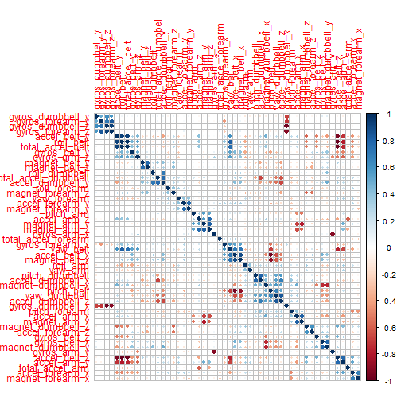

```r
correl_matrix <- cor(trainingAll[, -ncol(trainingAll)])

## Plot correlation matrix
corrplot(correl_matrix, order="hclust")
```

```r
## findCorrelation from caret package is useful to delete variables with correlation larger than user-defined
## threshold
high_corr <- findCorrelation(correl_matrix,.8)
```

Let's delete highly correlated predictors:

```r
trainingAll_with_corr <- trainingAll
trainingAll <- trainingAll[,-high_corr]
ncol(trainingAll)
```

```
## [1] 41
```

So, we remain with 40 predictors Now let's see how many of these numerical predictors have nearly zero variance:

```r
zerovar <- nearZeroVar(trainingAll[, -ncol(trainingAll)])
zerovar
```

```
## integer(0)
```

None of the remaining predictors has nearly zero variance.

Separate the predictors from the outcome variable:

```r
predictors <- trainingAll[, -ncol(trainingAll)]
```

Use caret's preProcess function to transform for skewness:

```r
predictors_processed <- preProcess(predictors, method = "BoxCox")
predictors_boxCox <- predict(predictors_processed, predictors)

## We can check which variable has been transformed using boxcox transformation
predictors_skewness <- sapply(predictors,skewness)
predictors_skewness_2 <- sapply(predictors_boxCox,skewness)
predictors_skewness - predictors_skewness_2
```

```
##             yaw_belt     total_accel_belt         gyros_belt_x
##                0.000                0.000                0.000
##         gyros_belt_y         gyros_belt_z        magnet_belt_x
##                0.000                0.000                0.000
##        magnet_belt_y        magnet_belt_z             roll_arm
##               -0.459                0.000                0.000
##            pitch_arm              yaw_arm      total_accel_arm
##                0.000                0.000                0.000
##          gyros_arm_x          gyros_arm_z          accel_arm_y
##                0.000                0.000                0.000
##          accel_arm_z         magnet_arm_x         magnet_arm_z
##                0.000                0.000                0.000
##        roll_dumbbell       pitch_dumbbell         yaw_dumbbell
##                0.000                0.000                0.000
## total_accel_dumbbell     gyros_dumbbell_y     gyros_dumbbell_z
##                0.000                0.000                0.000
##     accel_dumbbell_y    magnet_dumbbell_x    magnet_dumbbell_y
##                0.000                0.000                0.000
##    magnet_dumbbell_z         roll_forearm        pitch_forearm
##                0.000                0.000                0.000
##          yaw_forearm  total_accel_forearm      gyros_forearm_x
##                0.000                0.000                0.000
##      gyros_forearm_y      accel_forearm_x      accel_forearm_y
##                0.000                0.000                0.000
##      accel_forearm_z     magnet_forearm_x     magnet_forearm_y
##                0.000                0.000                0.000
##     magnet_forearm_z
##                0.000
```

As only magnet_belt_y predictor has been transformed by the Box-Cox pre-process we can forget about Box-Cox processing :)

# Split available trainingAll dataframe in 2 sets: for training and testing models

```r
set.seed(1234)
inTrain <- createDataPartition(y = trainingAll$classe, p=0.7, list=FALSE)
training <- trainingAll[inTrain, ]
testing <- trainingAll[-inTrain, ]
```

# Model fitting

## 1. random forest model

Try a random forest model with cross validation with 10 folders and 51 as number of trees to grow where 51 is a number close to the number of predictors :

```r
# train random forest predictive model with cross validation on 10 folds
# and Number of trees to grow set to predictors number
model_rf <- train(classe ~., data = training, method = "rf",
                 trControl = trainControl(method = "cv", number = 10),
                 ntree = 51, importance = TRUE)

# apply Random Forest model to testing set
model_rf_prediction <- predict(model_rf, testing)

# compute confusion matrix for rf model for accuracy and out of sample error
confusion_matrix <- confusionMatrix( model_rf_prediction, testing$classe)
confusion_matrix$table
```

```
##           Reference
## Prediction    A    B    C    D    E
##          A 1674   10    0    1    0
##          B    0 1126    8    0    0
##          C    0    3 1008    8    1
##          D    0    0   10  953    3
##          E    0    0    0    2 1078
```

```r
model_rf_accuracy <- confusion_matrix$overall["Accuracy"][[1]]
model_rf_accuracy
```

```
## [1] 0.9922
```

```r
# estimated out-of-sample error
out_of_sample_error_rf <- 1 - model_rf_accuracy
out_of_sample_error_rf
```

```
## [1] 0.007816
```

## 2. model based prediction

Try a model based prediction with cross validation with 10 folders :

```r
model_lda <- train(classe ~., data = training, method = "lda",
                 trControl = trainControl(method = "cv", number = 10))

# apply lda model to testing set
model_lda_prediction <- predict(model_lda, testing)

# compute confusion matrix for lda model
confusion_matrix <- confusionMatrix( model_lda_prediction, testing$classe)
confusion_matrix$table
```

```
##           Reference
## Prediction    A    B    C    D    E
##          A 1247  206   97   52   61
##          B  156  655   95   90  203
##          C  174  135  678  128  133
##          D   80   68  122  641  123
##          E   17   75   34   53  562
```

```r
model_lda_accuracy <- confusion_matrix$overall["Accuracy"][[1]]
model_lda_accuracy
```

```
## [1] 0.6428
```

```r
# estimated out-of-sample error
out_of_sample_error <- 1 - model_lda_accuracy
out_of_sample_error
```

```
## [1] 0.3572
```

## 3. boost with trees model

Try a boost with trees model with cross validation with 10 folders :

```r
model_gbm <- train(classe ~., data = training, method = "gbm", verbose=FALSE,
                 trControl = trainControl(method = "cv", number = 10))

# apply gbm model to testing set
model_gbm_prediction <- predict(model_gbm, testing)

# compute confusion matrix for gbm model
confusion_matrix <- confusionMatrix( model_gbm_prediction, testing$classe)
confusion_matrix$table
```

```
##           Reference
## Prediction    A    B    C    D    E
##          A 1647   47    0    4    2
##          B   20 1041   51    6    9
##          C    4   42  956   24   16
##          D    2    4   16  920   17
##          E    1    5    3   10 1038
```

```r
model_gbm_accuracy <- confusion_matrix$overall["Accuracy"][[1]]
model_gbm_accuracy
```

```
## [1] 0.9519
```

```r
# estimated out-of-sample error
out_of_sample_error <- 1 - model_gbm_accuracy
out_of_sample_error
```

```
## [1] 0.04809
```

# Predict the 20 requested tests with the best of the tried models

```r
final_predictions_based_on_rf <- predict(model_rf, testingAll)
final_predictions_based_on_lda <- predict(model_lda, testingAll)
final_predictions_based_on_gbm <- predict(model_gbm, testingAll)
```

Prediction done with random forest model:

```r
final_predictions_based_on_rf
```

```
##  [1] B A B A A E D B A A B C B A E E A B B B
## Levels: A B C D E
```

Prediction done with lda model:

```r
final_predictions_based_on_lda
```

```
##  [1] B A A C C C D D A A D A B A E A A B B B
## Levels: A B C D E
```

Prediction done with boost with trees model:

```r
final_predictions_based_on_gbm
```

```
##  [1] C A B A A E D B A A B C B A E E A B B B
## Levels: A B C D E
```

As you can see, all 3 predictions are not identical and I used the prediction generated by random forest model with cross validation with 10 folders and 51 as number of trees because it has the best accuracy:

```r
round(model_rf_accuracy, 3)
```

```
## [1] 0.992
```

# Prediction Assignment Submission

```r
pml_write_files = function(x, folder){
  n = length(x)
  for(i in 1:n){
    filename = paste0("./",folder,"/problem_id_",i,".txt")
    write.table(x[i],file=filename,quote=FALSE,row.names=FALSE,col.names=FALSE)
  }
}
pml_write_files(final_predictions_based_on_rf, "rf")
```

# Another try with lda and gbm models but without eliminating correlated predictors

As the 3 models have different predictions I try again lda and gbm models but without eliminating correlated predictors:

```r
inTrain <- createDataPartition(y = trainingAll_with_corr$classe, p=0.7, list=FALSE)
training <- trainingAll_with_corr[inTrain, ]
testing <- trainingAll_with_corr[-inTrain, ]
```

## 2.1 model based prediction without eliminating correlated predictors

Try a model based prediction with cross validation with 10 folders :

```r
model_lda <- train(classe ~., data = training, method = "lda",
                 trControl = trainControl(method = "cv", number = 10))

# apply lda model to testing set
model_lda_prediction <- predict(model_lda, testing)

# compute confusion matrix for lda model
confusion_matrix <- confusionMatrix( model_lda_prediction, testing$classe)
confusion_matrix$table
```

```
##           Reference
## Prediction    A    B    C    D    E
##          A 1373  171   96   56   45
##          B   39  749  107   37  182
##          C  117  119  666  117   88
##          D  137   46  133  727  100
##          E    8   54   24   27  667
```

```r
model_lda_accuracy <- confusion_matrix$overall["Accuracy"][[1]]
model_lda_accuracy
```

```
## [1] 0.7106
```

```r
# estimated out-of-sample error
out_of_sample_error <- 1 - model_lda_accuracy
out_of_sample_error
```

```
## [1] 0.2894
```

## 3.1 boost with trees model without eliminating correlated predictors

Try a boost with trees model with cross validation with 10 folders :

```r
model_gbm <- train(classe ~., data = training, method = "gbm", verbose=FALSE,
                 trControl = trainControl(method = "cv", number = 10))

# apply gbm model to testing set
model_gbm_prediction <- predict(model_gbm, testing)

# compute confusion matrix for gbm model
confusion_matrix <- confusionMatrix( model_gbm_prediction, testing$classe)
confusion_matrix$table
```

```
##           Reference
## Prediction    A    B    C    D    E
##          A 1651   26    0    1    1
##          B   12 1099   30    4    8
##          C    4   14  986   41    5
##          D    5    0    9  909   14
##          E    2    0    1    9 1054
```

```r
model_gbm_accuracy <- confusion_matrix$overall["Accuracy"][[1]]
model_gbm_accuracy
```

```
## [1] 0.9684
```

```r
# estimated out-of-sample error
out_of_sample_error <- 1 - model_gbm_accuracy
out_of_sample_error
```

```
## [1] 0.03161
```

```r
final_predictions_based_on_lda <- predict(model_lda, testingAll)
final_predictions_based_on_gbm <- predict(model_gbm, testingAll)
```

Prediction done with lda model:

```r
final_predictions_based_on_lda
```

```
##  [1] B A B C A E D D A A D A B A E A A B B B
## Levels: A B C D E
```

Prediction done with boost with trees model:

```r
final_predictions_based_on_gbm
```

```
##  [1] B A B A A E D D A A B C B A E E A B B B
## Levels: A B C D E
```